# Econometría: Regresión lineal simple

Verano 2020

[figure not shown]

## Transformaciones a una línea recta

En muchas ocasiones, nos enfrentamos a casos en los cuales el comportamiento o la relación de asociación entre las variables no es precisamente lineal.

Consideremos el siguiente caso en el cual se cuenta con el valor de viviendas en los suburbios de Boston a finales de los 70s, así como el porcentaje de población con el *status* más bajo.

## Ejemplo

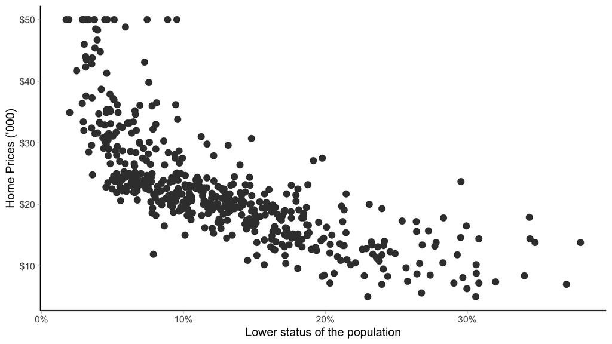

## Ejemplo

Ahora, considere el ajuste de un modelo de regresión lineal en el cual se quiere determinar el precio de la vivienda en función del porcentaje de población con el nivel más bajo:

\[ price_i= \beta_0 + \beta_1lowest_i + \epsilon_i \]

## Ejemplo: Estimación

```
##
## Call:
## lm(formula = "medv ~ lstat", data = base)
##
## Residuals:
##     Min      1Q  Median      3Q     Max
## -15.168  -3.990  -1.318   2.034  24.500
##
## Coefficients:
##             Estimate Std. Error t value Pr(>|t|)
## (Intercept) 34.55384    0.56263   61.41   <2e-16 ***
## lstat       -0.95005    0.03873  -24.53   <2e-16 ***
## ---
## Signif. codes:  0 '***' 0.001 '**' 0.01 '*' 0.05 '.' 0.1 ' ' 1
##
## Residual standard error: 6.216 on 504 degrees of freedom
## Multiple R-squared:  0.5441, Adjusted R-squared:  0.5432
## F-statistic: 601.6 on 1 and 504 DF,  p-value: < 2.2e-16
```

## Ejemplo: Residuales

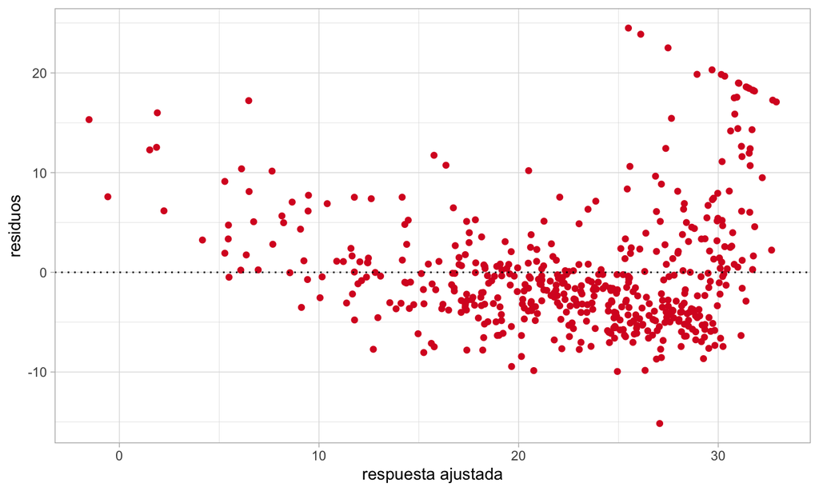

## Ejemplo: Residuales

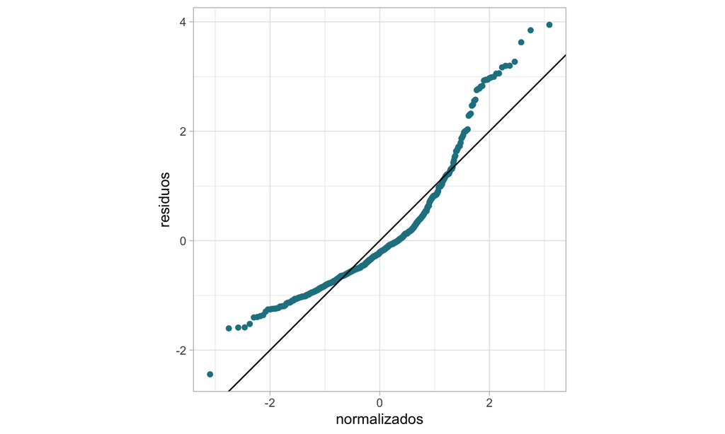

## Ejemplo: Análisis de varianza

```
## Analysis of Variance Table
##
## Response: medv
##            Df Sum Sq Mean Sq F value    Pr(>F)
## lstat       1  23244 23243.9  601.62 < 2.2e-16 ***
## Residuals 504  19472    38.6
## ---
## Signif. codes:  0 '***' 0.001 '**' 0.01 '*' 0.05 '.' 0.1 ' ' 1
```

## Transformación a una línea recta

Por lo tanto, como podemos observar, los residuales son indican que no hay un comportamiento del todo lineal entre la variable respuesta y el regresor, por lo tanto se propone realizar una transformación que permita **linealizar** dicha relación.

Para ello considere la siguiente transformación en el regresor \(lowest_i\) en la cual se aplica el logarítmo natural:

\[ lowest_i^* = \log\left(lowest_i\right) \] Considerando esta transformación, ajustamos nuevamente el modelo y observamos los resultados.

## Ajuste modelo linealizado

```
##
## Call:
## lm(formula = "medv ~ log(lstat)", data = base)
##
## Residuals:
##      Min       1Q   Median       3Q      Max
## -14.4599  -3.5006  -0.6686   2.1688  26.0129
##
## Coefficients:
##             Estimate Std. Error t value Pr(>|t|)
## (Intercept)  52.1248     0.9652   54.00   <2e-16 ***
## log(lstat)  -12.4810     0.3946  -31.63   <2e-16 ***
## ---
## Signif. codes:  0 '***' 0.001 '**' 0.01 '*' 0.05 '.' 0.1 ' ' 1
##
## Residual standard error: 5.329 on 504 degrees of freedom
## Multiple R-squared:  0.6649, Adjusted R-squared:  0.6643
## F-statistic:  1000 on 1 and 504 DF,  p-value: < 2.2e-16
```

## Residuales modelo ajustado

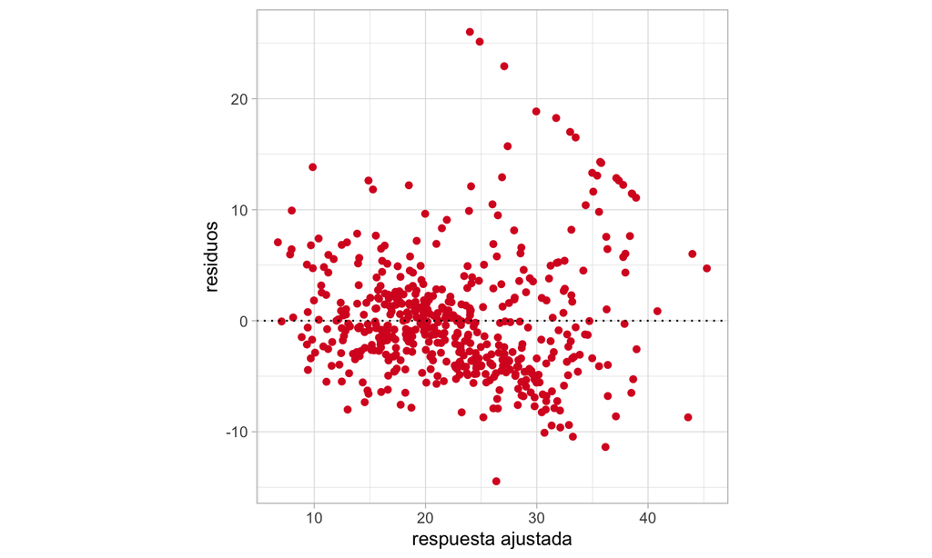

## Residuales modelo ajustado

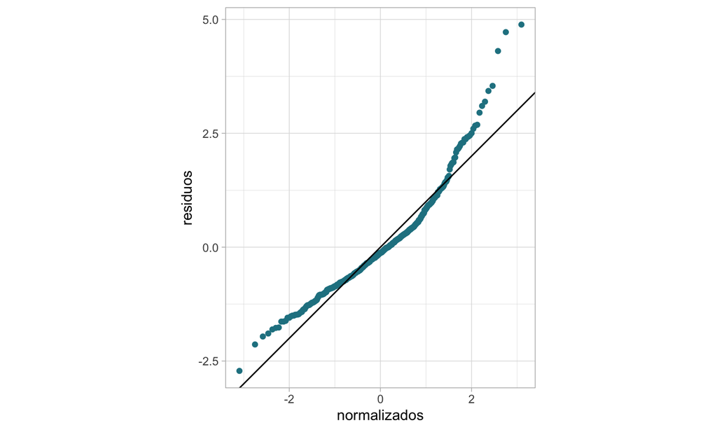

## Moraleja

Por lo tanto, en muchas ocasiones es posible enfrentarnos a casos en los cuales será necesario realizar algún tipo de transformación en los regresores para garantizar un compartamiento lineal entre la variable respuesta y el regresor.

**¿Qué tipo de transformaciones se pueden utilizar?**

Por otro lado, determinar el tipo de transformación que se requiere aplicar a los datos no necesariamente es tarea sencilla y en ocasiones requiere cierto nivel de experiencia o de conocimiento del contexto de la información, sin embargo a continuación estudiaremos los tipos de transformaciones más comunes.

## Funciones linealizables

| Función Linealizable | Transformación | Forma Lineal |
| --- | --- | --- |
| \(y=\beta_0x^{\beta_1}\) | \(Y=\log(y)\), \(X = \log(x)\) | \(Y=\log(\beta_0) + \beta_1X\) |
| \(y=\beta_0e^{\beta_1x}\) | \(Y=\log(y)\) | \(Y=\log(\beta_0) + \beta_1x\) |
| \(y=\beta_0 + \beta_1\log(x)\) | \(X = \log(x)\) | \(y = \beta_0 +\beta_1X\) |
| \(y= \frac{x}{\beta_0x+\beta_1}\) | \(Y = \frac{1}{y}\), \(X = \frac{1}{x}\) | \(Y=\beta_0 + \beta_1X\) |

**Observación** Notemos que la linealidad en el modelo se puede obtener transformando el regresor (como en nuestro ejemplo), la respuesta o ambos. Para garantizar la linealidad se deben explorar todas estas posibilidades.

## Interpretación

| Función Linealizable | Transformación | Forma Lineal | Elasticidades \(\frac{dy}{dx}\frac{x}{y}\) |
| --- | --- | --- | --- |
| \(y=\beta_0x^{\beta_1}\) | \(Y=\log(y)\), \(X = \log(x)\) | \(Y=\log(\beta_0) + \beta_1X\) | \(\beta_1\) |
| \(y=\beta_0e^{\beta_1x}\) | \(Y=\log(y)\) | \(Y=\log(\beta_0) + \beta_1x\) | \(\beta_1x\) |
| \(y=\beta_0 + \beta_1\log(x)\) | \(X = \log(x)\) | \(y = \beta_0 +\beta_1X\) | \(\beta_1\frac{1}{x}\) |
| \(y= \frac{x}{\beta_0x+\beta_1}\) | \(Y = \frac{1}{y}\), \(X = \frac{1}{x}\) | \(Y=\beta_0 + \beta_1X\) |  |

## Modelo de elasticidad de precios

Una aplicación muy útil de los modelos de regresión en la teoría económica es la obtención de las elasticidades precio de bienes de consumo o productos. Generalmente, la relación que guarda la demanda de un bien y su precio no es lineal, sino multiplicativa, como sugiere el modelo Cobb-Douglas.

Por ello, cuando pensamos en el modelo de demanda de un bien tenemos que

\[ ventas_i = \beta_0*precio_i^{\beta_1}. \] Modelo en el cual claramento podemos observar que la relación que guardan no es lineal. Por lo tanto para ajustar correctamente el modelo con análisis de regresión lineal debemos aplicar una transformación.

## Modelo de elasticidad de precios

Considere la siguiente transformación, aplicaremos la función logarítmo de ambos lados de la ecuación de manera que

\[ \log\left(ventas_i\right) = \log\left(\beta_0*precio_i^{\beta_1}\right) \\ = \log\left(\beta_0\right) + \beta_1\log\left(precio_i\right), \]

con lo que obtemos un modelo linealizado y como se mencionó anteriormente, el coeficiente (parámetro) \(\beta_1\) representa una **elasticidad**, i.e, por cada cambio porcental en la variable \(precio_i\) se observa un cambio porcentual en la respuesta, en este caso las \(ventas_i\).

Por lo tanto, en este modelo \(\beta_1\) representa la elasticidad precio *ceteris paribus*.

## Modelo de elasticidad de precios

Considere el modelo

\[ \log\left(ventas\right) = \log\left(\beta_0\right)+\beta_1\log\left(precio\right), \]

luego, si derivamos ambos lados de la ecuación tenemos que

\[ \frac{\delta}{\delta\,ventas}\;\log\left(ventas\right)=\frac{\delta}{\delta_i\;precio}\; \beta_1\log\left(precio\right) \] y como

\[ \frac{\delta}{\delta\,Y}\;\log\left(Y\right) \equiv \frac{\delta\; Y}{Y} \]

## Modelo de elasticidad de precios

Tenemos que

\[ \frac{\delta\,ventas}{ventas}=\beta_1\frac{\delta_i\;precio}{precio}. \]

Despejando para \(\beta_1\) tenemos que

\[ \beta_1 =\frac{\delta\;ventas}{\delta\;precio}\frac{precio}{ventas} \] Por lo tanto, \(\beta_1\) representa la elasticidad precio pues es el cambio en las ventas ante cambios en el precio

\[ \beta_1 = \frac{\Delta\; ventas}{\Delta\; precio} \]

## Modelo de elasticidad de precios

**Observaciones**

Basados en la teoría económica tenemos que

| Valor | Descripción |
| --- | --- |
| \(\beta_1 = 0\) | Demanda perfectamente inelástica |
| \(-1 < \beta_1 < 0\) | Demanda inelástica |
| \(\beta_1 = -1\) | Elasticidad unitaria |
| \(\beta_1 < -1\) | Demanda elástica |
| \(\beta_1 = \infty\) | Demanda perfecamente elástica |

## Modelo de elasticidad de precios

Sin embargo en muchas ocasiones se pueden estimar elasticidades tales que \(\beta_1 >0\), en este caso se debe profundizar en el análisis de los datos puesto que dichas elasticidades se obtienen a partir de comportamiento observado antes de concluir que se trata de un bien Veblen o Giffen.

Finalmente, si se desea estimar el cambio porcentual que se observará en las ventas ante un cambio porcentual de \(k\%\) en el precio, basta con calcular

\[ \Delta\; ventas = (1+k)^{\beta_1}-1 \]

## Ejemplo

Considere la ventas en unidades a nivel mensual, durante 45 meses, de una bebida refrescante que se comercializa en las tienditas de la esquina o misceláneas. Asimismo considere el precio por unidad de dicho producto.

```
##      fecha            ventas_unidades precio_unidad
##  Min.   :2016-05-01   Min.   :1895    Min.   : 9.501
##  1st Qu.:2017-04-01   1st Qu.:2039    1st Qu.:12.024
##  Median :2018-03-01   Median :2149    Median :12.653
##  Mean   :2018-03-02   Mean   :2175    Mean   :12.603
##  3rd Qu.:2019-02-01   3rd Qu.:2255    3rd Qu.:13.243
##  Max.   :2020-01-01   Max.   :2699    Max.   :14.866
```

## Ejemplo: EDA

Observamos el diagrama de dispersión de los datos originales

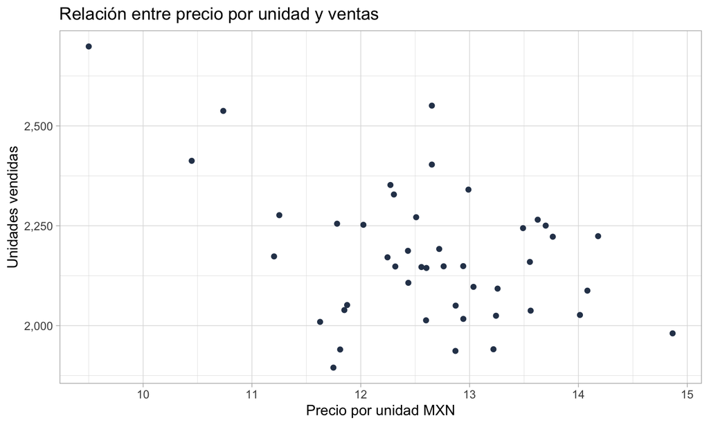

## Ejemplo: EDA

Ahora, transformamos los datos aplicando la transformación logartimo natural tanto en la respuesta como en el regresor para obtener un modelo \(log-log\).

En este caso, tenemos que el diagrama de dispersión de los datos transformados es el siguiente

## Ejemplo: EDA

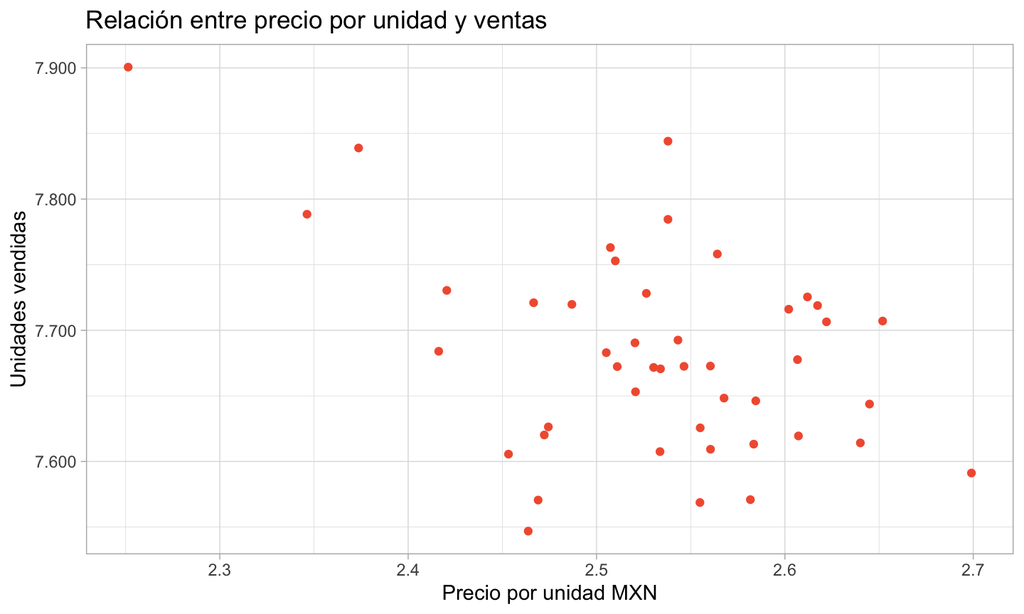

## Ejemplo: EDA

Notemos que al aplicar la transformación, el comportamiento entre las variables no se modificó considerablemente, sin embargo recordemos que para poder dar la interpretación de elasticidad al coeficiente \(\beta_1\) es necesario emplear el modelo \(log-log\).

De hecho el coeficiente de correlación lineal en los datos originales es de -0.419 mientras que con los datos transformados es de -0.428, por lo que la «ganancia» en linealidad no es relevante.

## Ejemplo: Ajuste del modelo

```
##
## Call:
## lm(formula = ventas_unidades ~ precio_unidad, data = dt_mod)
##
## Residuals:
##      Min       1Q   Median       3Q      Max
## -0.16083 -0.04233 -0.00287  0.06063  0.16540
##
## Coefficients:
##               Estimate Std. Error t value Pr(>|t|)
## (Intercept)     8.6715     0.3185   27.23  < 2e-16 ***
## precio_unidad  -0.3912     0.1258   -3.11  0.00332 **
## ---
## Signif. codes:  0 '***' 0.001 '**' 0.01 '*' 0.05 '.' 0.1 ' ' 1
##
## Residual standard error: 0.07032 on 43 degrees of freedom
## Multiple R-squared:  0.1836, Adjusted R-squared:  0.1646
## F-statistic: 9.671 on 1 and 43 DF,  p-value: 0.003317
```

## Ejemplo: Residuales

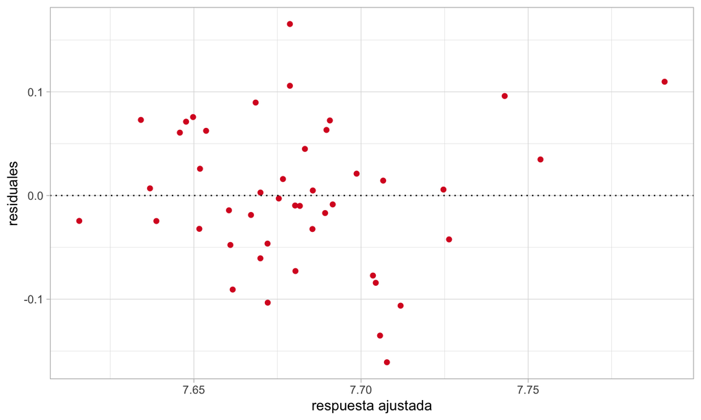

## Ejemplo: Residuales

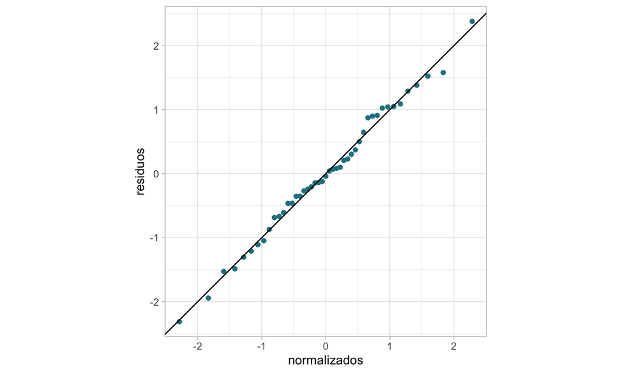

## Ejemplo: Análisis de varianza

```
## Analysis of Variance Table
##
## Response: ventas_unidades
##               Df   Sum Sq  Mean Sq F value   Pr(>F)
## precio_unidad  1 0.047823 0.047823  9.6712 0.003317 **
## Residuals     43 0.212629 0.004945
## ---
## Signif. codes:  0 '***' 0.001 '**' 0.01 '*' 0.05 '.' 0.1 ' ' 1
```

## Ejemplo: Conclusión

- Por lo tanto, concluimos que el bien es relativamente inelástico o poco sensible ante cambios en el precio
- Asimismo observamos que el precio explica únicamente alrededor de 18% de la variación total de las ventas
- Lo anterior sugiere que existen otros factores que afectan/ayudan explicar los movimientos en las ventas
- Para mejorar el ajuste del modelo se recomienda incorporar otros regresores que ayuden a explicar mejor el comportamiento de las ventas (regresión lineal múltiple)